# Redes Neurais Artificiais

Exercício 4 - Perceptron

Vítor Gabriel Reis Caitité - 2016111849

1/9/2021

## Função que calcula a resposta de um perceptron simples

Abaixo está a função que calcula a resposta de um perceptron simples e é utilizada nas questões da lista.

```r
#Função que calcula a resposta de um perceptron simples.
yperceptron <- function(xvec, w, par){
  # xvec: vetor de entrada
  # w: vetor de pesos
  # par: se adiciona ou não o vetor de 1s na entrada
  # yperceptron: resposta do perceptron
  if ( par==1){
    xvec<-cbind ( 1 , xvec )
  }
  u <- xvec %*% w
  y <- 1.0 * (u>=0)
  return(as.matrix(y))
}
```

## Treinamento do perceptron

A função abaixo é uma implementação possível, em R, para o algoritmo de treinamento do Perceptron. Essa função é utilizada na resolução dos exercícios da lista.

```r
trainPerceptron <- function ( xin , yd , eta , tol , maxepocas , par )
{
  dimxin<-dim( xin )
  N <-dimxin[ 1 ]
  n<-dimxin[ 2 ]
  if ( par==1){
    wt<-as.matrix ( runif(n+1) - 0.5)
    xin<-cbind ( 1 , xin )
  } else {
    wt<-as.matrix ( runif ( n ) - 0.5)
  }
  nepocas<-0
  eepoca<-tol + 1

  evec<-matrix ( nrow =1 , ncol=maxepocas )
  while( ( nepocas < maxepocas ) && ( eepoca>tol ) )
  {
    ei2<-0
    xseq<-sample(N)
    for ( i in 1:N)
    {
      irand<-xseq [i]
      yhati<-1.0 * ( ( xin[
        irand , ] %*% wt ) >= 0 )
      ei<-yd[irand]- yhati
      dw<-as.vector(eta) * as.vector(ei) * xin[ irand  , ]
      wt<-wt+dw
      ei2<-ei2 + ei * ei
    }
    nepocas<-nepocas+1
    evec[ nepocas ]<-ei2/N

    eepoca<-evec[nepocas]
  }
  retlist<-list ( wt, evec[ 1:nepocas ] )
  return (retlist)
}
```

## Questão 1

Inicialmente, devem-se amostrar duas distribuições normais no espaço R^2 , ou seja, duas distribuições com duas variáveis cada (Ex: x1 e x2 ). As distribuição são caracterizadas como N (2, 2, σ^2 ) e N (4, 4, σ^2 ). Nesta atividade o aluno irá fazer o treinamento do perceptron afim de encontrar o vetor de pesos w e encontrar a superfície de separação.

#### *Resolução:*

#### Geração de ditribuições normais

Inicialmente, foram amostradas as amostras como requisitado. As distribuições são caracterizadas como N(2, 2, σ^2) e N(4, 4, σ^2).

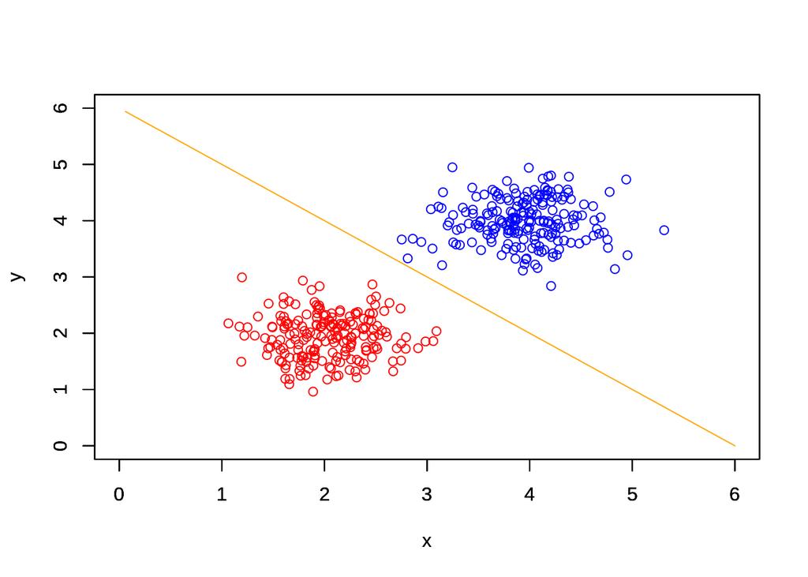

```r
rm(list = ls())

library("plot3D")
source("~/Documents/UFMG/9/Redes Neurais/listas/lista 4/trainPerceptron.R")
source("~/Documents/UFMG/9/Redes Neurais/listas/lista 4/yperceptron.R")

s1<-0.4
s2<-0.4
nc<-200

# Distribuição normal N(2, 2, σ^2)
xc1<-matrix(rnorm(nc*2), ncol=2)*s1 + t(matrix((c(2,2)), ncol=nc, nrow=2))
# Distribuição normal N(4, 4, σ^2)
xc2<-matrix(rnorm(nc*2), ncol=2)*s2 + t(matrix((c(4,4)), ncol=nc, nrow=2))

# Plotando dados:
plot(xc1[,1], xc1[,2], col = "red", xlim=c(0,6), ylim=c(0,6), ylab="y", xlab="x")
par(new=T)
plot(xc2[,1], xc2[,2], col = "blue", xlim=c(0,6), ylim=c(0,6), ylab="y", xlab="x")

# Reta que separa os dados (inferida visualmente)
x1_reta<-seq(6/100,6,0.01)
x2_reta<- -x1_reta+6
par(new=TRUE)
plot(x1_reta, x2_reta, type="l", col="orange", xlim=c(0,6), ylim=c(0,6), ylab="", xlab="")
```

#### Treinamento do modelo

Geradas as amostras, o próximo passo foi o treinamento do modelo, ou seja encontrar o vetor de pesos w:

```r
# Treinando modelo:

# Definindo entradas da função (Nesse ex. todos os dados etão sendo usados para treino):
xin = as.matrix(rbind(xc1,xc2))
yc1_train<-matrix(0, nrow=nc)
yc2_train<-matrix(1, nrow=nc )
yp<-as.matrix(rbind(yc1_train, yc2_train))
retlist<-trainPerceptron(xin, yp, 0.1, 0.01, 100, 1) #função que faz o treinamento do perceptron
w<-retlist[[1]]
print(w)
```

```
##             [,1]
## [1,] -0.62552874
## [2,]  0.06135224
## [3,]  0.16312511
```

#### Teste do modelo

Por fim foi realizado o teste do modelo e a geração dos plots requisitados.

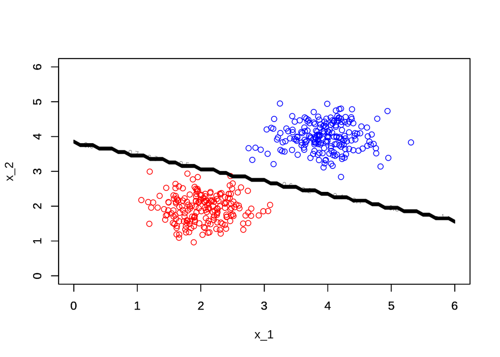

```r
# Teste do modelo:
# Pontos de teste
seqi<-seq(0,6,0.1)
seqj<-seq(0,6,0.1)

# Cálculo do perceptron para pontos de teste
M<-matrix(0, nrow=length(seqi), ncol=length(seqj))
ci<-0
for(i in seqi) {
  ci<-ci+1
  cj<-0
  for(j in seqj) {
    cj<-cj+1
    x<-matrix(c(i,j), nrow = 1, ncol = 2)
    M[ci,cj]<-yperceptron(x,w,1)
  }
}

# Plotando resultados:
plot(xc1[,1], xc1[,2], xlim=c(0,6), ylim=c(0,6), col="red", ylab="x_2", xlab="x_1")
par(new=TRUE)
plot(xc2[,1], xc2[,2], xlim=c(0,6), ylim=c(0,6), col="blue",  ylab="", xlab="")
par(new=TRUE)
contour(seqi, seqj, M, xlim=c(0,6), ylim=c(0,6), ylab="", xlab="")
```

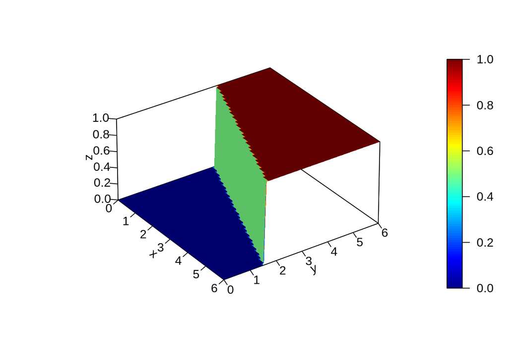

```r
persp3D(seqi, seqj, M, counter=T, theta=55, phi=30, r=40, d=0.1, expand=0.5, ltheta=90, lphi=180, shade=0.4, ticktype="detailed", nticks=5)
```

## Questão 2

Nesta segunda atividade o aluno deverá criar um conjunto de amostras de cada uma das duas distribuições do Exercício 1, ou seja, 200 amostras da classe 1 e 200 amostras da classe 2. O aluno deverá utilizar essas amostras para criar dois conjuntos balanceados, um chamado de conjunto de treinamento que será usado para achar o pesos w e outro chamado de teste que servirá para avaliar a performance do seu separador dado pelos pesos encontrados no treinamento. O conjunto de treinamento irá conter 70% da amostras e o de teste 30%. Essa distribuição deve ser obrigatoriamente aleatória. Após a separação dos dois conjuntos o aluno usará o conjunto de treinamento para encontrar os pesos do perceptron e utilizará o conjunto de teste para avaliar a performance do perceptron simples. Apresente a acurácia e a matriz de confusão.

#### *Resolução:*

#### Separando amostras em amostras de treinamento e teste

```r
rm(list = ls())

library("plot3D")
library("bnlearn")
library("caret") #Para plotar matriz de confusão
source("~/Documents/UFMG/9/Redes Neurais/listas/lista 4/trainPerceptron.R")
source("~/Documents/UFMG/9/Redes Neurais/listas/lista 4/yperceptron.R")


#_______________________________________________________________________________
#Gerando dados:
# Distribuição normal N(2, 2, σ^2)
xc1<-matrix(rnorm(200*2), ncol=2)*0.4 + t(matrix((c(2,2)), ncol=200, nrow=2))
# Distribuição normal N(4, 4, σ^2)
xc2<-matrix(rnorm(200*2), ncol=2)*0.4 + t(matrix((c(4,4)), ncol=200, nrow=2))

#_______________________________________________________________________________
# Separando em conjunto de treinamento e conjunto de teste:

# Seleção das amostra de Treinamento:
ntrain<-200*0.7 # Número de amostras, de cada uma das classes, selecionadas para treinamento.
seqc1<-sample(200) #Gera um vetor com números int de 1 a 200 em posições aleatórias
xc1_train<-xc1[seqc1[1:ntrain],] # 140 amostras de treino
yc1_train<-matrix(0, nrow=ntrain) # 0 - amostras distribuidas em torno de 2
seqc2<-sample(200) #Gera um vetor com números int de 1 a 50 em posições aleatórias
xc2_train<-xc2[seqc2[1:ntrain],] # 140 amostras de treino
yc2_train<-matrix(1, nrow=ntrain) # 1 - amostras distribuídas em trono de 4

# Seleção das amostra de Teste:
xc1_test<-xc1[seqc1[(ntrain+1):200],] # 60 amostras de teste
yc1_test<-matrix(0, (nrow=200-ntrain)) # 0 - amostras distribuidas em torno de 2
xc2_test<-xc2[seqc2[(ntrain+1):200],] # 60 amostras de teste
yc2_test<-matrix(1, (nrow=200-ntrain)) # 1 - amostras distribuídas em trono de 4

#Concatenando dados das 2 classes
xin_train<-as.matrix(rbind(xc1_train, xc2_train))
yd_train<-rbind(yc1_train, yc2_train)
xin_test<-as.matrix(rbind(xc1_test, xc2_test))
yd_test<-rbind(yc1_test, yc2_test)
```

#### Treinamento do modelo

Abaixo pode-se observar o vetor de pesos w.

```r
#_______________________________________________________________________________
# Treinamento:

retlist<-trainPerceptron(xin_train, yd_train, 0.1, 0.01, 100, 1)
wt<-retlist[[1]]
print(wt)
```

```
##             [,1]
## [1,] -0.79887274
## [2,]  0.07578914
## [3,]  0.19275931
```

#### Teste da performance do perceptron

Nesse passo foi utilizado o conjunto de teste para avaliar a performance do perceptron simples. Apresentou-se, abaixo, a acurácia, a matriz de confusão. entre outros dados.

```r
#_______________________________________________________________________________
# Teste:

yt<-yperceptron(xin_test,wt,1)
acc<-1-(t(yd_test-yt)%*%(yd_test-yt))/60
paste("Acurácia: ", acc*100, '%')
```

```
## [1] "Acurácia:  100 %"
```

```r
print(confusionMatrix(table(yt, yd_test)))
```

```
## Confusion Matrix and Statistics
##
##    yd_test
## yt   0  1
##   0 60  0
##   1  0 60
##
##                Accuracy : 1
##                  95% CI : (0.9697, 1)
##     No Information Rate : 0.5
##     P-Value [Acc > NIR] : < 2.2e-16
##
##                   Kappa : 1
##
##  Mcnemar's Test P-Value : NA
##
##             Sensitivity : 1.0
##             Specificity : 1.0
##          Pos Pred Value : 1.0
##          Neg Pred Value : 1.0
##              Prevalence : 0.5
##          Detection Rate : 0.5
##    Detection Prevalence : 0.5
##       Balanced Accuracy : 1.0
##
##        'Positive' Class : 0
##
```